# Quanteda Text Models

Diana York

21 February 2021

# **Introduction**

This code through will explore word networks and word clouds through the quanteda.textmodels package. Additional libraries such as the harrypotter and janeaustenr packages will also be used to demonstrate these concepts.

## **Content Overview**

Specifically, we’ll demonstrate how to create networks and clouds by cleaning and preparing the text documents available in harrypotter and janeaustenr packages. We will primarily be looking at how to create networks and clouds using text from books such as “Harry Potter and the Sorcerer’s Stone,” by J.K. Rowling, and “Pride and Prejudice,” by Jane Austen.

## **Why You Should Care**

Word networks and word clouds are an important part to text analysis. They allow us to visualize word frequency and understand the patterns that are created in text. Networks and clouds also help people that are not fluent in text analysis understand the meaning behind text. Text analysis is also becoming increasingly popular in customer service and marketing industries. According to Pure Speech Technology (2020), “Whether it’s customer feedback, phone transcripts or lengthy feedback surveys, text analytics helps teams make quantitative and qualitative sense from text data.” Therefore, networks and clouds are worth exploring because of there applicability in the business world.

## **Learning Objectives**

We will first create a word network and word cloud for using the harrypotter package. Once we have discussed how they are created, we will create a network and cloud using the janeaustenr package.

# **Word Networks and Word Clouds**

Here, we will demonstrate how to create word networks and word clouds.

## **Further Exposition**

This is based on the work of Kenneth Benoit, the creator of the quanteda package. Benoit’s goal was to create an easy way to analyze and manage text documents. Over the years, the package has been updated with tools to make manipulating text easier (Benoit et al., 2018).

## **Harry Potter Word Network**

Our first example is a word network of the Harry Potter. For this example, we will be using the first book which is known in the package as philosophers_stone. The great thing about the harrypotter package is that it contains all seven books, so you can always use another book in the series. To view the available books, view the package documentation.

Before we begin, you will need to load the following packages.

```r
library(harrypotter)
library(janeaustenr)
library(dplyr)
library(pander)
library(quanteda)
library(readtext)
library(quanteda.textmodels)
```

The main package that we will be working with is quanteda.textmodels. This package will allow us to create word networks, word clouds, word xrays, etc.

Now, we need to clean and prepare the text. To do this, first make the text lowercase. Next, we must convert the text into a corpus. This step is crucial because it will allow us to access the tokens and create a dfm later.

```r
potter <- tolower(philosophers_stone)
potter1 <- corpus(potter, docvars = data.frame(chapter = paste("chapter", 1:length(potter))))
summary(potter1) %>% pander()
```

| Text | Types | Tokens | Sentences | chapter |
| --- | --- | --- | --- | --- |
| text1 | 1187 | 5643 | 58 | chapter 1 |
| text2 | 984 | 4128 | 29 | chapter 2 |
| text3 | 1130 | 4630 | 47 | chapter 3 |
| text4 | 1057 | 4761 | 83 | chapter 4 |
| text5 | 1625 | 8372 | 84 | chapter 5 |
| text6 | 1408 | 7949 | 111 | chapter 6 |
| text7 | 1268 | 5445 | 79 | chapter 7 |
| text8 | 1036 | 3594 | 35 | chapter 8 |
| text9 | 1312 | 6131 | 69 | chapter 9 |
| text10 | 1208 | 5207 | 48 | chapter 10 |
| text11 | 1037 | 4152 | 47 | chapter 11 |
| text12 | 1388 | 6729 | 78 | chapter 12 |
| text13 | 1002 | 3930 | 64 | chapter 13 |
| text14 | 1022 | 4354 | 63 | chapter 14 |
| text15 | 1271 | 6437 | 99 | chapter 15 |
| text16 | 1446 | 8277 | 136 | chapter 16 |
| text17 | 1370 | 7101 | 112 | chapter 17 |

Once we have created the corpus, we want to construct a tokens object. Since we are dealing with a novel, we know that there is going to be a lot of punctuation. We want to remove the punctuation so that it does not mess with our word frequency.

```r
toks.potter <- tokens(potter1, remove_punct = T)
```

In addition to removing punctuation, we also want to remove stopwords. Once the stopwords are removed, we can create a document-feature matrix.

```r
potter.nostop <- tokens_select(toks.potter, pattern = stopwords("en"), selection = "remove")

dfmat_potter <- dfm(potter.nostop)
```

If you would like to view the top words in the text, you can use the function topfeatures().This will also come in handy when we create our word cloud.

```r
topfeatures(dfmat_potter, 10) %>% pander()
```

| harry | said | ron | hagrid | back | hermione | one | got | like | get |
| --- | --- | --- | --- | --- | --- | --- | --- | --- | --- |
| 1212 | 794 | 410 | 336 | 261 | 257 | 254 | 198 | 194 | 194 |

Now we are ready to construct a word network. An important thing to note about a word network, is that it relies on feature co-occurrences (fcm). This is because a word network is measuring how often words occur together. Therefore, we need to be able to identify the frequency that which words occur together. We do this by using the fcm function.

```r
fcm.potter <- fcm(dfmat_potter) #  feature co-occurrence matrix (FCM) records the number of co-occurrences of tokens.
topfeatures(fcm.potter, 10) %>% pander()
```

Table continues below

| ron | harry | hermione | hagrid | said | snape | malfoy | one |
| --- | --- | --- | --- | --- | --- | --- | --- |
| 811151 | 802466 | 505163 | 446086 | 321852 | 268484 | 212146 | 211327 |

| professor | neville |
| --- | --- |
| 207913 | 198167 |

Since there are a lot of words, lets limit to the top 50. We can then use the function fcm_select() to select our top 50 words from our fcm.

```r
top <- names(topfeatures(fcm.potter, 50))

fcm.potter.select <- fcm_select(fcm.potter, pattern = top, selection = "keep")
```

We are now ready to map our word network! To do this, we use the function textplot_network() from the quanteda.textmodels package. Let’s look at the words that occur together 80% of the time.

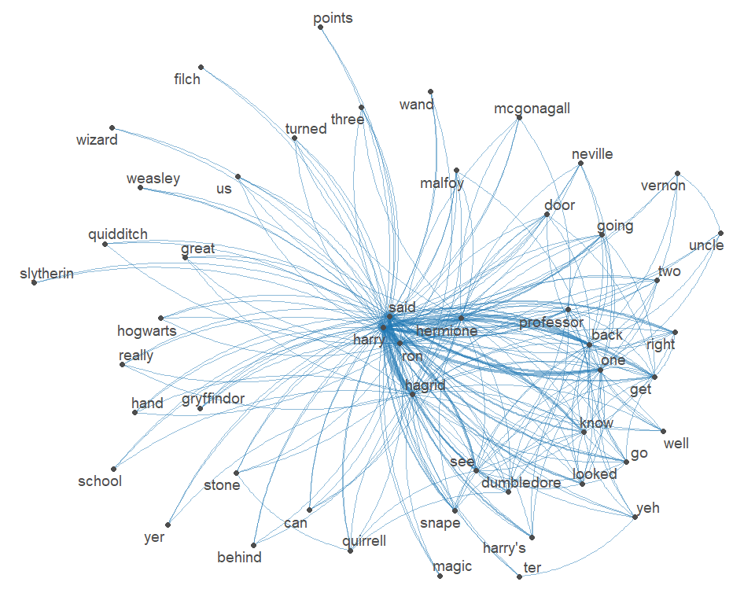

```r
set.seed(144)
textplot_network(fcm.potter.select, min_freq = 0.8)
```

## **Harry Potter Word Cloud**

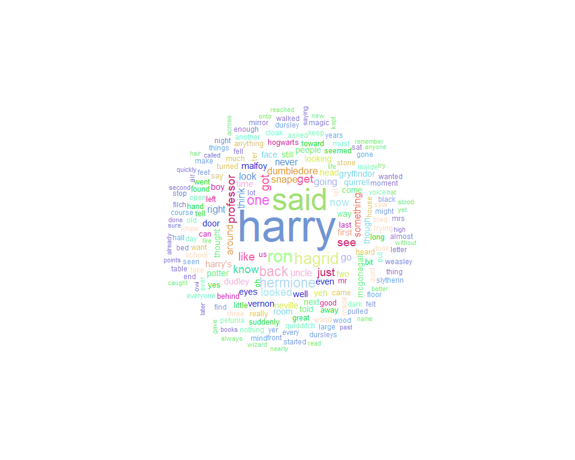

```r
library(randomcoloR)
n <- 200
textplot_wordcloud(dfmat_potter, max_words = 200, color = randomColor(n))
```

## **Jane Austen Word Network**

Now let’s create a word network of Jane Austen’s, “Pride and Prejudice.” Note that there are six books available in the janeaustenr package. We will follow the same process used for our Harry Potter word network to create our Jane Austen word network.

```r
pride <- tolower(prideprejudice)
pride1 <- corpus(pride, docvars = data.frame(chapter = paste("chapter", 1:length(pride))))
toks.pride <- tokens(pride1, remove_punct = T)

eliz.nostop <- tokens_select(toks.pride, pattern = stopwords("en"), selection = "remove")

dfmat_eliz <- dfm(eliz.nostop)

topfeatures(dfmat_eliz, 10) %>% pander()
```

| mr | elizabeth | said | darcy | mrs | much | must | bennet | miss | jane |
| --- | --- | --- | --- | --- | --- | --- | --- | --- | --- |
| 785 | 597 | 401 | 373 | 343 | 326 | 305 | 294 | 283 | 264 |

```r
fcm.eliz <- fcm(dfmat_eliz) #  feature co-occurrence matrix (FCM) records the number of co-occurrences of tokens.
topfeatures(fcm.eliz, 10) %>% pander()
```

Table continues below

| darcy | miss | elizabeth | collins | wickham | sister | never | letter |
| --- | --- | --- | --- | --- | --- | --- | --- |
| 925 | 816 | 774 | 681 | 664 | 428 | 413 | 399 |

| gardiner | without |
| --- | --- |
| 387 | 368 |

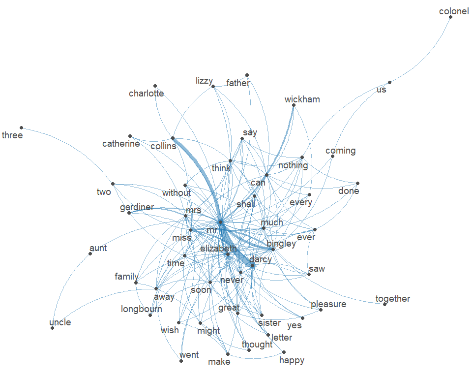

```r
top <- names(topfeatures(fcm.eliz, 50))

fcm.eliz.select <- fcm_select(fcm.eliz, pattern = top, selection = "keep")

set.seed(144)
textplot_network(fcm.eliz.select, min_freq = 0.8)
```

## **Jane Austen Word Cloud**

We can also create a word cloud for Pride and Prejudice using the same method we used for Harry Potter.

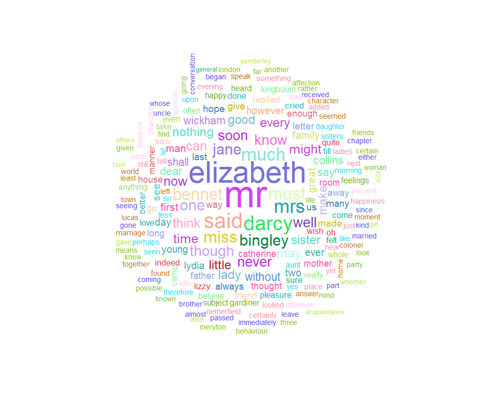

```r
n <- 200
textplot_wordcloud(dfmat_eliz, max_words = 200, color = randomColor(n))
```

# **Further Resources**

Learn more about harrypotter, janeaustenr, and quanteda with the following:

- Resource I [Learn more about quanteda](https://tutorials.quanteda.io/)
- Resource II [Learn more about harrypotter](https://rstudio-pubs-static.s3.amazonaws.com/300624_8260952d1f0346969e65f41a97006bf5.html)
- Resource III [Learn more about janeaustenr](https://cran.r-project.org/web/packages/janeaustenr/janeaustenr.pdf)

# **Works Cited**

This code through references and cites the following sources:

- Pure Speech Technology (2020). Source I. [Text Analysis Use Cases](https://www.purespeechtechnology.com/text-analysis-text-analytics-text-mining/#title-applicationsUseCasesTextAnalysis)
- Benoit, K., Watanabe, K., Wang, H., Nulty, P., Obeng, A., Müller, S., & Matsuo, A. (2018). Source II. [Quanteda](https://www.theoj.org/joss-papers/joss.00774/10.21105.joss.00774.pdf)